# Reproducible Research Course Project 1

JPV

Sunday, April 19, 2015

### Analysis 1 : Mean Total Number of steps taken per day (with missing values).

```r
raw_data<-read.csv("activity.csv",header=T,sep=",")
day_aggr<-aggregate(steps~date, data=raw_data, sum)
summary(day_aggr)
```

```
##          date        steps
##  2012-10-02: 1   Min.   :   41
##  2012-10-03: 1   1st Qu.: 8841
##  2012-10-04: 1   Median :10765
##  2012-10-05: 1   Mean   :10766
##  2012-10-06: 1   3rd Qu.:13294
##  2012-10-07: 1   Max.   :21194
##  (Other)   :47
```

```r
median_value<-as.integer(median(day_aggr$steps))
mean_value<-as.integer(mean(day_aggr$steps))
```

**The mean and median for the number of steps taken per day is 10766 and 10765 respectively.**

Here is the histogram showing frequency of number of stes per day shown below :

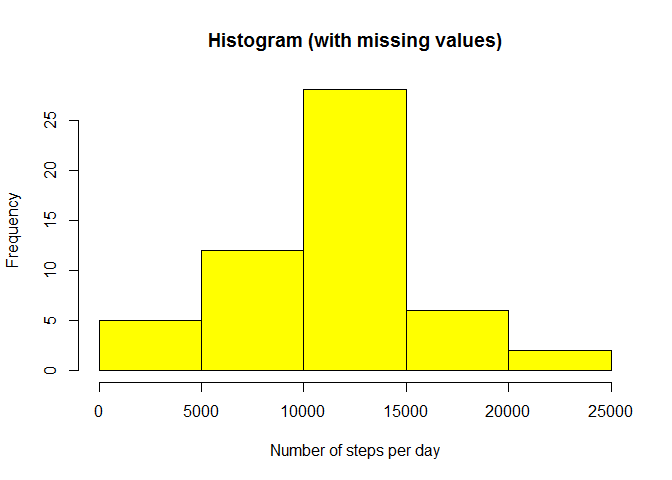

```r
hist(day_aggr$steps, xlab="Number of steps per day" ,main="Histogram (with missing values)",col="yellow")
```

### Analysis 2 : Average daily activity pattern Analysis (with missing values)

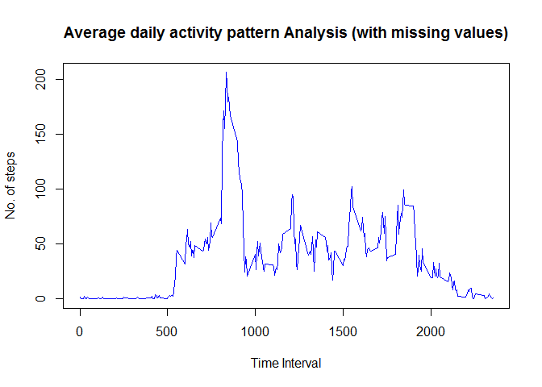

```r
int_aggr<-aggregate(steps~interval, data=raw_data, mean)
plot(int_aggr$interval,int_aggr$steps, type="l",col="blue", xlab="Time Interval",ylab="No. of steps",main="Average daily activity pattern Analysis (with missing values)")
```

**Interval (5 mins) with maximum number of average steps shown below;**

```r
int_aggr[which.max(int_aggr$steps),]
```

```
##     interval    steps
## 104      835 206.1698
```

### Analysis 3: Missing values (NA’s) in the data set

```r
Total_rows<-nrow(raw_data)
steps_NA<-nrow(raw_data[is.na(raw_data$steps),])
date_NA<-nrow(raw_data[is.na(raw_data$date),])
interval_NA<-nrow(raw_data[is.na(raw_data$interval),])
```

Number of records in the raw data : 17568

Missing values for “steps” column : 2304

Missing values for “date” column : 0

Missing values for “interval” column : 0

### Imputing missing values strategy:

```r
raw_data_No_NA<-raw_data[!is.na(raw_data$steps),]
NA_data<-raw_data[is.na(raw_data$steps),]
NA_data_merge<-merge(NA_data,int_aggr,by="interval")
names(NA_data_merge)[4]<-paste("steps")
NA_data_impute<-NA_data_merge[,c(4,3,1)]
clean_data<-rbind (raw_data_No_NA,NA_data_impute)
clean_data_day_aggr<-aggregate(steps~date, data=clean_data, sum)
```

Cleaned data is then aggregated at day level to perform Analysis 1 for imputed missing values

### Analysis 4 : Repeat Analysis 1 with the dataset with imputed missing values

```r
summary(clean_data_day_aggr)
```

```
##          date        steps
##  2012-10-01: 1   Min.   :   41
##  2012-10-02: 1   1st Qu.: 9819
##  2012-10-03: 1   Median :10766
##  2012-10-04: 1   Mean   :10766
##  2012-10-05: 1   3rd Qu.:12811
##  2012-10-06: 1   Max.   :21194
##  (Other)   :55
```

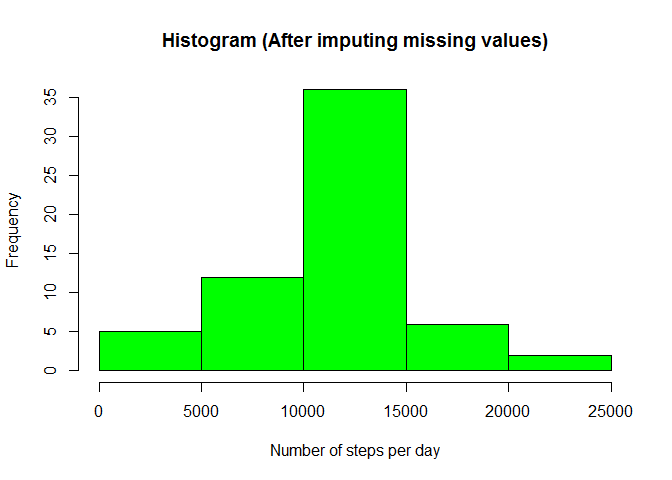

```r
median_value_clean<-as.integer(median(clean_data_day_aggr$steps))
mean_value_clean <-as.integer(mean(clean_data_day_aggr$steps))
hist(clean_data_day_aggr$steps, xlab="Number of steps per day" ,main="Histogram (After imputing missing values)",col="green")
```

Do these values differ from the estimates from the first part of the assignment?

What is the impact of imputing missing data on the estimates of the total daily number of steps ?

- After imputing, median and mean are close to each other (infact they are equal after imputing). This indicates that the imputing strategy followed in the analysis is good.

### Analysis 5 : Are there differences in activity patterns between wwekdays and weekends ?

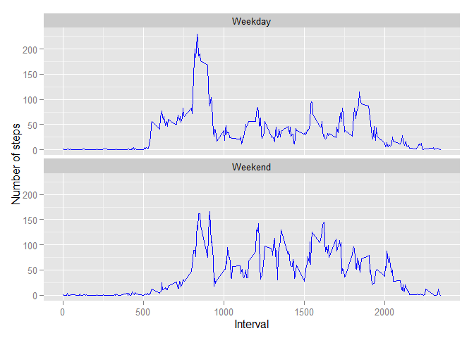

```r
library(ggplot2)

day <- weekdays(as.Date(clean_data$date))
dayofweek <- vector()
for (i in 1:nrow(clean_data)) {
  if (day[i] == "Saturday") {
    dayofweek[i] <- "Weekend"
  } else if (day[i] == "Sunday") {
    dayofweek[i] <- "Weekend"
  } else {
    dayofweek[i] <- "Weekday"
  }
}
clean_data$dayofweek <- dayofweek
clean_data$dayofweek <- factor(clean_data$dayofweek)

steps_day <- aggregate(steps ~ interval + dayofweek, data = clean_data, mean)
names(steps_day) <- c("interval", "dayofweek", "steps")

ggplot(steps_day, aes(x=interval, y=steps)) +
  geom_line(color="blue") +
  facet_wrap(~ dayofweek, nrow=2, ncol=1) +
  labs(x="Interval", y="Number of steps")
```

———————————————————– End of Report —————————————————————–